# Giant Frogs in Bend

Corey Dow-Hygelund, Mozilla

Tlell Wolf, Bend Science Station

Jay Bowerman, Sunriver Nature Center

1/1/2019

## Data Loading

The dataset is contained in an Excel (.xlsx) spreadsheet, located in the subdirectory `data`. The raw statistics are on the sheet *All Female raw statistics*. Lets load it in and take a quick look.

```r
library(readxl)

file_path <- 'data/Female size statistics.2.xlsx'
data_df <- read_excel(file_path, range=(cell_cols('B:G')),
                      sheet="All Females raw statistics")

head(data_df)
```

```
## # A tibble: 6 x 6
##      CR    MC    SR    DM    CP   LSA
##   <dbl> <dbl> <dbl> <dbl> <dbl> <dbl>
## 1    42    40    40    40    47    42
## 2    42    42    40    40    48    42
## 3    42    43    40    40    50    43
## 4    43    44    40    40    50    44
## 5    43    45    40    40    51    44
## 6    43    45    40    40    51    45
```

## Summary statistics

Before plotting, let’s take a look at summary numbers. This helps ensure that the plots are being correctly rendered.

There are a total of 4505 observations, for 6 sites.

```r
summary(data_df)
```

```
##        CR              MC              SR              DM
##  Min.   :42.00   Min.   :40.00   Min.   :40.00   Min.   :40.00
##  1st Qu.:55.00   1st Qu.:60.00   1st Qu.:54.00   1st Qu.:52.00
##  Median :64.00   Median :65.00   Median :62.00   Median :61.00
##  Mean   :63.13   Mean   :64.29   Mean   :60.73   Mean   :60.17
##  3rd Qu.:71.00   3rd Qu.:69.00   3rd Qu.:67.00   3rd Qu.:68.00
##  Max.   :85.00   Max.   :82.00   Max.   :89.00   Max.   :83.00
##  NA's   :4233    NA's   :3514                    NA's   :2044
##        CP             LSA
##  Min.   :47.00   Min.   :42.00
##  1st Qu.:63.00   1st Qu.:50.00
##  Median :70.00   Median :55.00
##  Mean   :69.65   Mean   :56.85
##  3rd Qu.:77.00   3rd Qu.:62.00
##  Max.   :95.00   Max.   :83.00
##  NA's   :4370    NA's   :4313
```

Sunriver (SR) has significantly more observations than the other sites, with the second highest Dilman Meadows (DM) containing only half the measurements. This will influence plots based upon distributions.

## Data Reshaping

The data is currently in the so-called *wide* format, where each value of the site location variable is an independent column. Let’s tranform it to the *long* format, where each observation is contained in a single column, with another single column denoting site location.

In addition, there are many `NA` (NULL) values, due to the difference in number of observations across sites. These are easily removed with `na.omit`.

```r
library(tidyr)
data_long = na.omit(gather(data_df, site_location, size,
                           CR:LSA, factor_key=FALSE))
head(data_long)
```

```
## # A tibble: 6 x 2
##   site_location  size
##   <chr>         <dbl>
## 1 CR               42
## 2 CR               42
## 3 CR               42
## 4 CR               43
## 5 CR               43
## 6 CR               43
```

There are now 8556 unique observations for *all* sites.

## Plotting

In the following violin/boxplot, the order from left-right is either determined by a.) 1st observation/row in dataset, b.) the factor order. The desire is for the plot order to reflect the median frog size for readability. Therefore, we set the factor order accordingly.

```r
site_medians <- sort(apply(data_df, 2, median, na.rm=TRUE))
site_median_names <- names(site_medians)
site_max <- sort(apply(data_df, 2, max, na.rm=TRUE))
data_long$site_location <- factor(data_long$site_location, names(site_medians))
```

Also we retrieve the number of observation as a character vector to include in the plots

```r
num_obs <- as.character(table(data_long$site_location))
```

Finally we add an additional factor column for plotting counts in ridge plots: bona-fide hack.

```r
library(plyr)
data_long$site_loc_1 <- mapvalues(data_long$site_location, from=site_median_names,
                                  paste(paste(levels(data_long$site_location), num_obs, sep='\n('), ')', sep =''))
data_long$site_loc_2 <- mapvalues(data_long$site_location, from=site_median_names,
                                  paste(paste(levels(data_long$site_location), num_obs, sep=' ('), ')', sep =''))
```

### Optimal

#### Violin

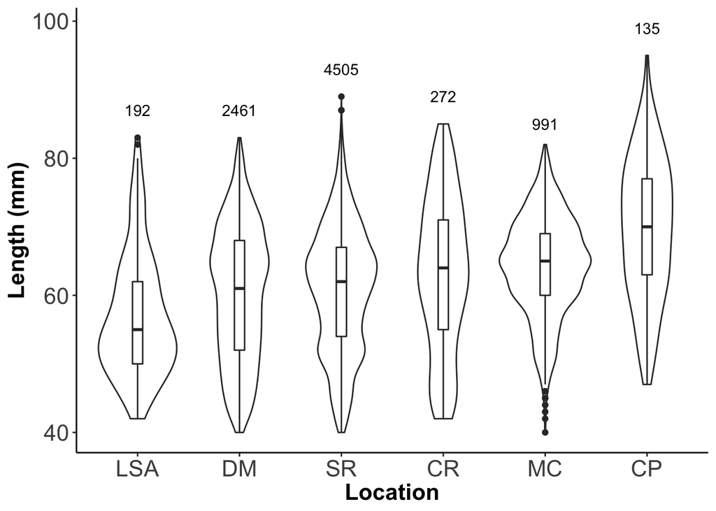

```r
library(ggplot2)

violin_count_yloc <- site_max + c(5, 4, 10, 4, -4, 4) # Custom pretty offset

p <- ggplot(data_long, aes(x=site_location, y=size)) +
  labs(x = 'Location', y = 'Length (mm)') +
  theme_classic() +
  theme(axis.text=element_text(size=16),
        axis.title=element_text(size=16,face="bold")) +
  geom_violin() +
  geom_boxplot(width=0.1) +
  geom_text(data=data.frame(), aes(x=site_median_names, y=violin_count_yloc, label=num_obs))

p
```

#### Ridge

If we are fortunate enough for color, the ridge plot is a great choice.

The following has the counts below the labels

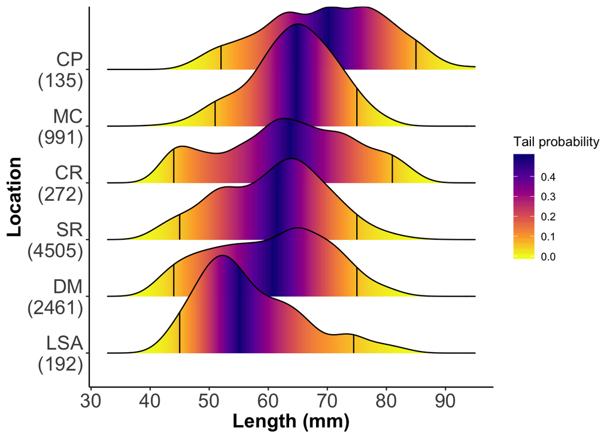

```r
library(ggridges)

ggplot(data_long, aes(x=size, y=site_loc_1, fill=0.5 - abs(0.5-..ecdf..))) +
  stat_density_ridges(geom = "density_ridges_gradient", calc_ecdf = TRUE, to=max(data_long$size),
                      quantiles=c(0.05, 0.95), quantile_lines=TRUE) +
  scale_fill_viridis_c(name = "Tail probability", direction = -1, option = 'C') +
  # geom_text(x=site_median_names, y=site_location, label=num_obs) +
  labs(x = 'Length (mm)', y = 'Location') +
  theme_classic() +
  theme(axis.text=element_text(size=16),
        axis.title=element_text(size=16,face="bold")) +
  scale_x_continuous(breaks = scales::pretty_breaks(n = 5))
```

The following has the counts inline with the labels

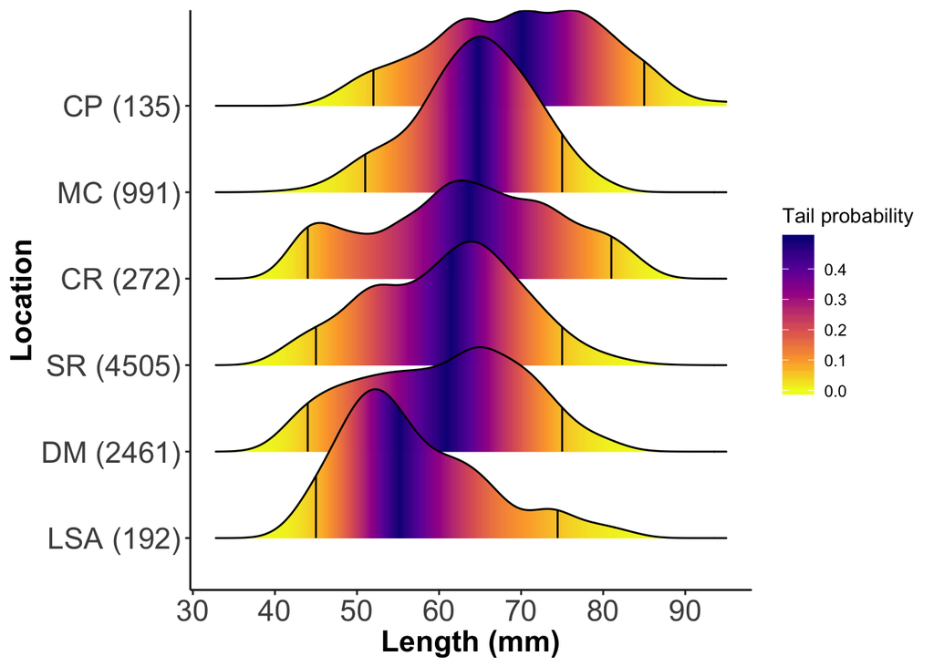

```r
ggplot(data_long, aes(x=size, y=site_loc_2, fill=0.5 - abs(0.5-..ecdf..))) +
  stat_density_ridges(geom = "density_ridges_gradient", calc_ecdf = TRUE, to=max(data_long$size),
                      quantiles=c(0.05, 0.95), quantile_lines=TRUE) +
  scale_fill_viridis_c(name = "Tail probability", direction = -1, option = 'C') +
  scale_x_continuous(breaks = scales::pretty_breaks(n = 5)) +
  labs(x = 'Length (mm)', y = 'Location') +
  theme_classic() +
  theme(axis.text=element_text(size=16),
        axis.title=element_text(size=16,face="bold"))
```

### Violin/Boxplot

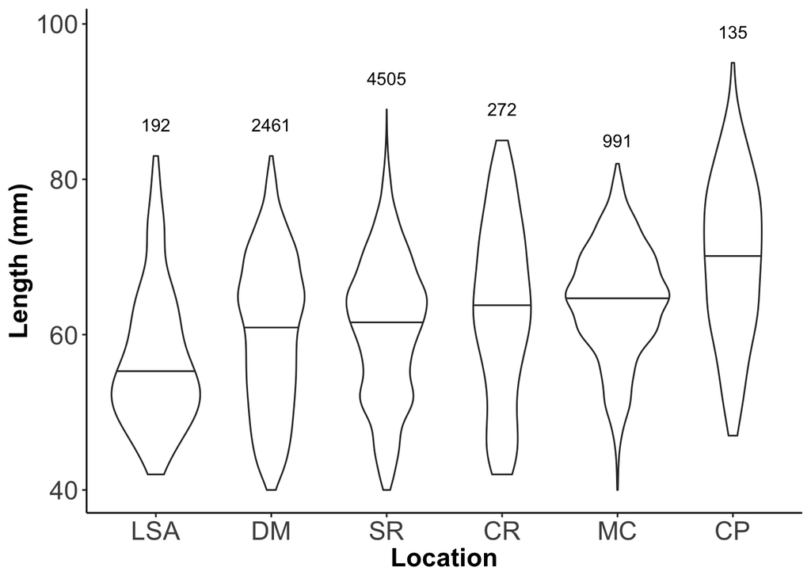

```r
library(ggplot2)

violin_count_yloc <- site_max + c(5, 4, 10, 4, -4, 4) # Custom pretty offset

p <- ggplot(data_long, aes(x=site_location, y=size)) +
  labs(x = 'Location', y = 'Length (mm)') +
  theme_classic() +
  theme(axis.text=element_text(size=16),
        axis.title=element_text(size=16,face="bold"))
#   geom_violin(scale='count')
p +  geom_violin(draw_quantiles = c(0.5)) +
  geom_text(data=data.frame(), aes(x=site_median_names, y=violin_count_yloc, label=num_obs))
```

Standard boxplot

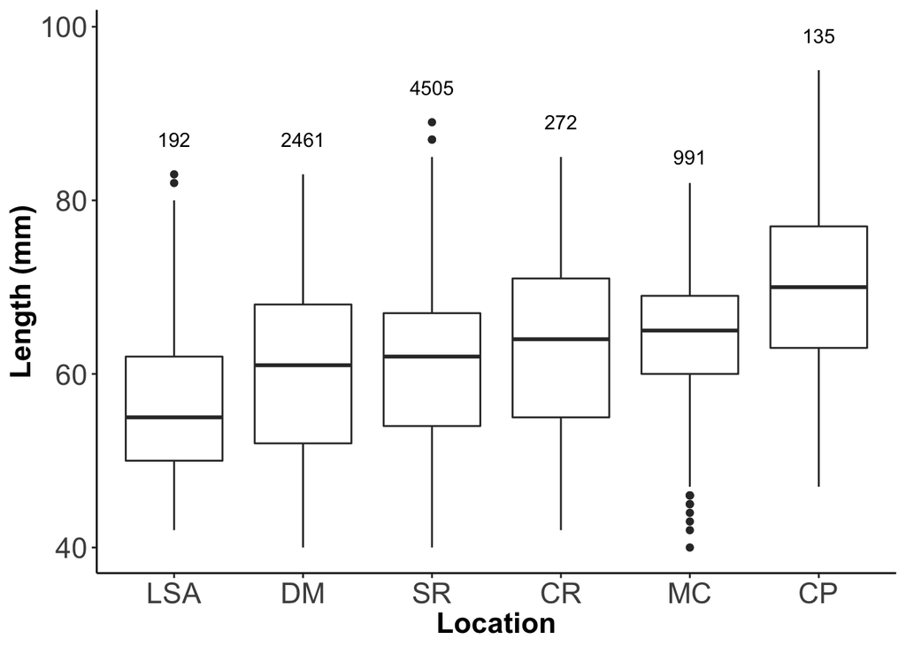

```r
p + geom_boxplot() +
  geom_text(data=data.frame(), aes(x=site_median_names, y=violin_count_yloc, label=num_obs))
```

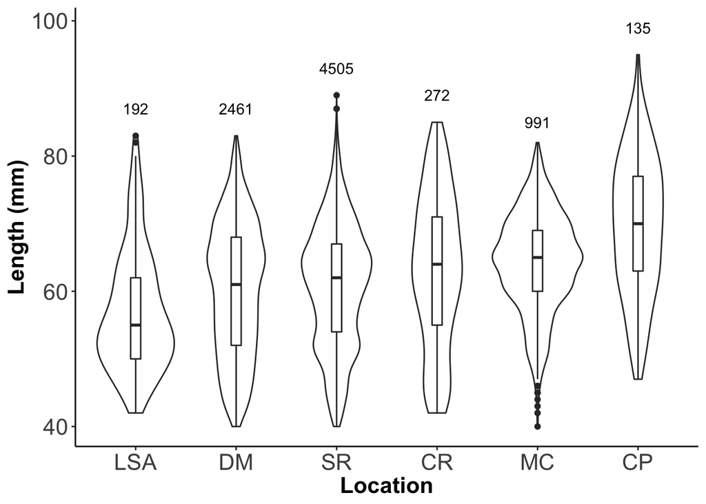

```r
p +
  geom_violin() +
  geom_boxplot(width=0.1) +
  geom_text(data=data.frame(), aes(x=site_median_names, y=violin_count_yloc, label=num_obs))
```

Producing the violin plot, where the violin area is scaled by the number of counts

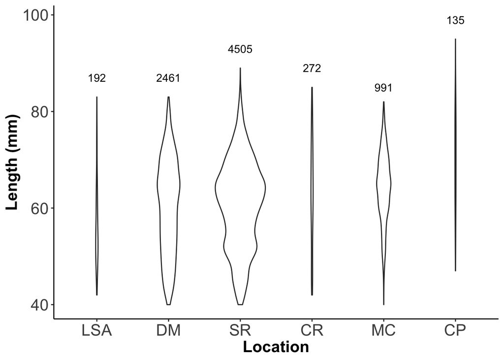

```r
p +
  geom_violin(scale='count') +
  geom_text(data=data.frame(), aes(x=site_median_names, y=violin_count_yloc, label=num_obs))
```

### Ridge

The ridge plot consists of the histograms being plotted one above the other. This enables direct comparison, in a manner that is intuitive.

Histograms without converting to densities

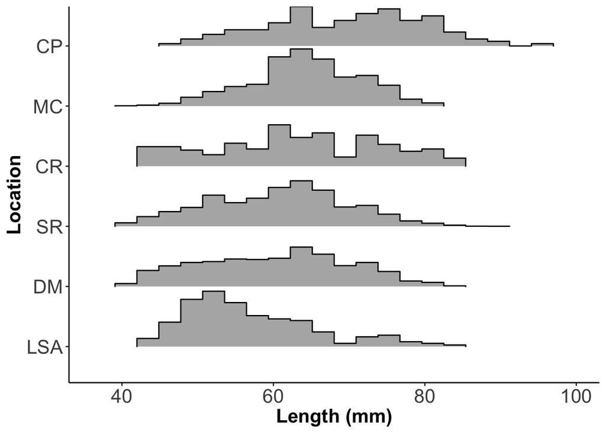

```r
ggplot(data_long, aes(x=size, y=site_location, height = ..density..)) +
  labs(x = 'Length (mm)', y = 'Location') +
  theme_classic() +
  theme(axis.text=element_text(size=16),
        axis.title=element_text(size=16,face="bold")) +
  geom_density_ridges(stat = "binline", bins = 20, scale = 0.95, draw_baseline = FALSE)
```

Converting to densities, which is easier on the eye.

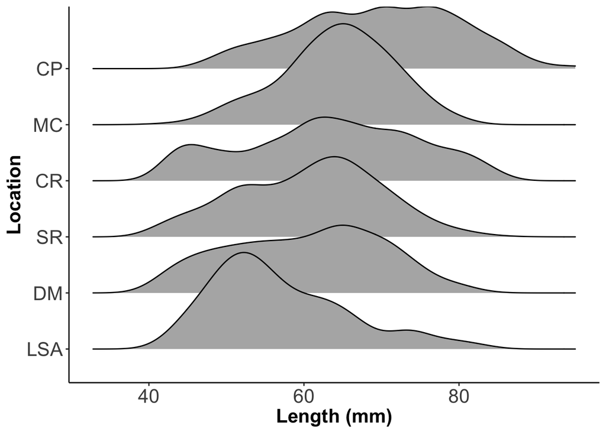

```r
p <- ggplot(data_long, aes(x=size, y=site_location)) +
  labs(x = 'Length (mm)', y = 'Location') +
  theme_classic() +
  theme(axis.text=element_text(size=16),
        axis.title=element_text(size=16,face="bold"))
p + geom_density_ridges(to=max(data_long$size))
```

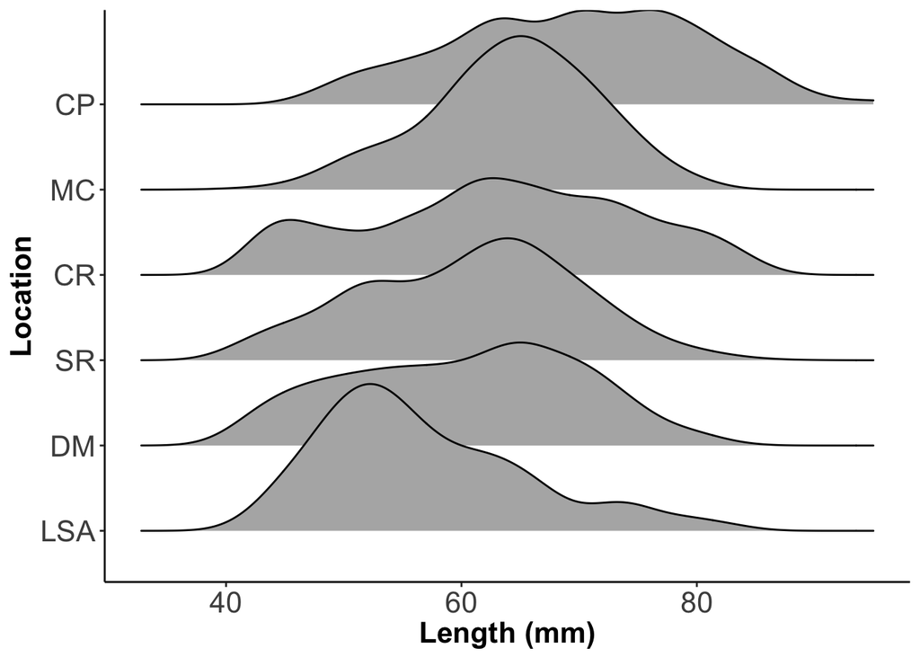

```r
p <- ggplot(data_long, aes(x=size, y=site_location)) +
  labs(x = 'Length (mm)', y = 'Location') +
  theme_classic() +
  theme(axis.text=element_text(size=16),
        axis.title=element_text(size=16,face="bold"))
p + geom_density_ridges(to=max(data_long$size))
```

Reducing the overlap between the histograms to zero.

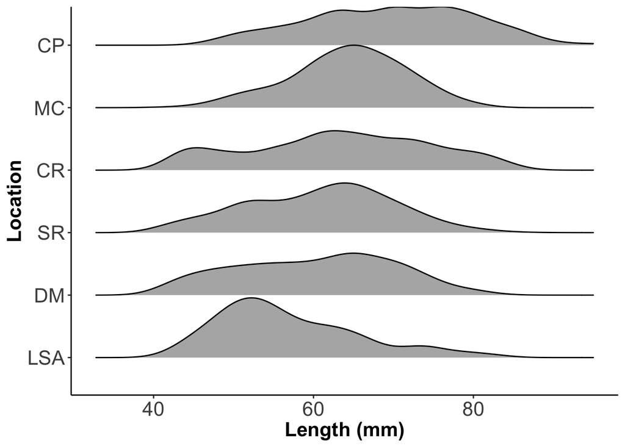

```r
p + geom_density_ridges(scale = 1, to=max(data_long$size))
```

Adding in quantiles

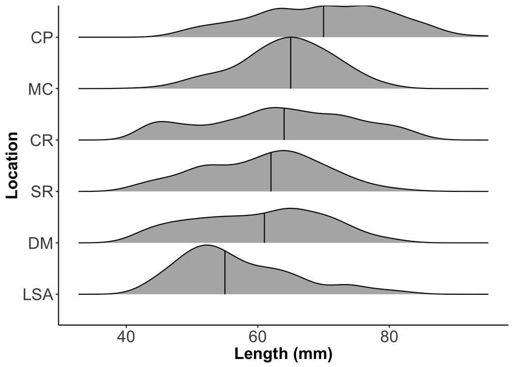

```r
p + geom_density_ridges(scale = 1, quantile_lines=TRUE, quantiles=2, to=max(data_long$size))
```